# TP8

## Exercice 1: test sur la moyenne

```r
data <- read.table("~/Personal/University/Semestre_4/401_STA/TP/Donnees/apnee.csv",header=TRUE,sep=",")
tailleH <- data[data$sexe==0,"taille"]
moyest <- mean(tailleH)
varest <- var(tailleH)
```

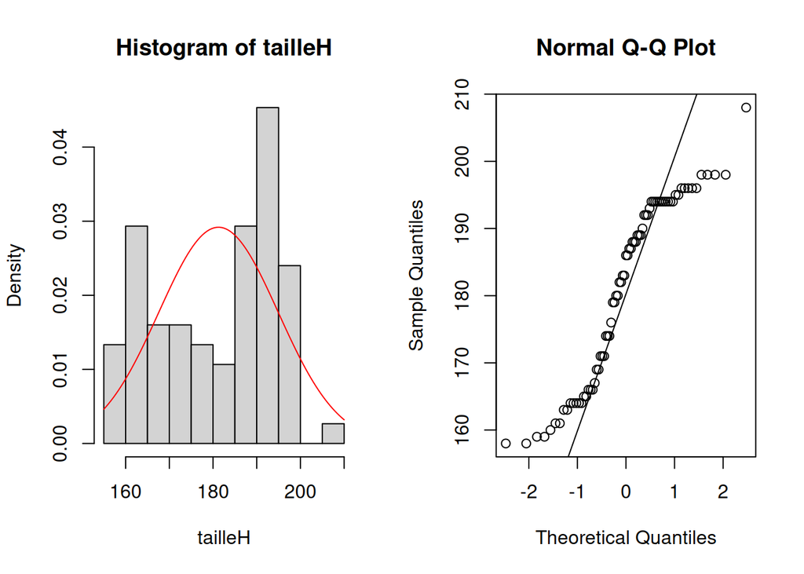

```r
par(mfrow=c(1,2))
hist(tailleH,probability=TRUE)
curve(dnorm(x,moyest,sqrt(varest)),add=T,col="red")
qqnorm(tailleH)
qqline(tailleH)
```

L’échantillon ne semble pas suivre une loi normale.

5. n étant grand, d’après le Théorème Central Limite (TCL), les conditions sont remplies, même si tailleH ne suit pas une loi normale.

```r
mu0 <- 184
n <- length(tailleH)
tcalc <- (moyest-mu0)/(sd(tailleH)/sqrt(n))
(pvalue <- pt(tcalc,n-1))
```

```
## [1] 0.0430009
```

Mêmes résultats en utilisant directement t.test:

```r
t.test(tailleH,mu=184,alternative="less")
```

```
##
##  One Sample t-test
##
## data:  tailleH
## t = -1.7401, df = 74, p-value = 0.043
## alternative hypothesis: true mean is less than 184
## 95 percent confidence interval:
##      -Inf 183.8826
## sample estimates:
## mean of x
##  181.2533
```

Pour tout risque choisi supérieur à 4.3%, on pourra refuser H0 et conclure que $\mu$ est inférieur à 184. Si on choisit le seuil classique de 5%, on refuse donc H0 et on conclu que $\mu$ est inférieur à 184.

```r
t.test(tailleH,mu=184,alternative="two.sided")
```

```
##
##  One Sample t-test
##
## data:  tailleH
## t = -1.7401, df = 74, p-value = 0.086
## alternative hypothesis: true mean is not equal to 184
## 95 percent confidence interval:
##  178.1082 184.3985
## sample estimates:
## mean of x
##  181.2533
```

Pour tout risque choisi supérieur à 8.6%, on pourra refuser H0 et conclure que $\mu$ est différent de 184. Le seuil classiquement utilisé de 5% ne permet donc pas de conclure que $\mu$ est différent de 184: on est dans le cas d’une faible présomption contre l’hypothèse nulle.

## Exercice 2: test sur la variance

```r
var0 <- 200
tcalc <- (n-1)*var(tailleH)/var0
alpha <- seq(0.01,0.1,0.01)
rejected <- tcalc<qchisq(alpha/2,n-1) | tcalc>qchisq(1-alpha/2,n-1)
kable(data.table(alpha=alpha,rejected=rejected))
```

| alpha | rejected |
| --- | --- |
| 0.01 | FALSE |
| 0.02 | FALSE |
| 0.03 | FALSE |
| 0.04 | FALSE |
| 0.05 | FALSE |
| 0.06 | FALSE |
| 0.07 | FALSE |
| 0.08 | FALSE |
| 0.09 | FALSE |
| 0.10 | FALSE |

Pour tous les risques testés ici, on ne peut pas rejeter l’hypothèse H0.

```r
(pvalue <- 2*min(pchisq(tcalc,n-1,lower.tail=TRUE),pchisq(tcalc,n-1,lower.tail=FALSE)))
```

```
## [1] 0.7238141
```

La p-valeur est grande, il n’existe pas de risque raisonable pour lequel on peut rejeter l’hypothèse H0.

## Exercice 3: test sur une proportion

```r
nbsucess <- sum(data$taille>180)
n <- nrow(data)
(p <- nbsucess/n)
```

```
## [1] 0.56
```

```r
p*n>10 & (1-p)*n>10
```

```
## [1] TRUE
```

```r
alpha <- 0.1
Binf <- p-sqrt(p*(1-p)/n)*qnorm(1-alpha/2)
Bsup <- p+sqrt(p*(1-p)/n)*qnorm(1-alpha/2)
cat("Intervalle de confiance: [",Binf," ; ",Bsup,"]\n")
```

```
## Intervalle de confiance: [ 0.4783516  ;  0.6416484 ]
```

```r
p0 <- 0.5
tcalc <- (p-p0)/sqrt((p0*(1-p0)/n))
pvalue <- 2*(1-pnorm(abs(tcalc)))
cat("p-valeur:",pvalue,"\n")
```

```
## p-valeur: 0.2301393
```

$p_0$=0.5 est dans l’intervalle de confiance de niveau 90%, la p-valeur est grande, il n’existe donc pas de risque raisonable permettant de rejeter l’hypothèse H0.

```r
prop.test(nbsucess,n,p=0.5,conf.level=0.90,alternative="two.sided")
```

```
##
##  1-sample proportions test with continuity correction
##
## data:  nbsucess out of n, null probability 0.5
## X-squared = 1.21, df = 1, p-value = 0.2713
## alternative hypothesis: true p is not equal to 0.5
## 90 percent confidence interval:
##  0.4728784 0.6437695
## sample estimates:
##    p
## 0.56
```

Rappel: prop.test n’utilise pas l’approximation du cours, il est valable sans condition.